# Assignment 5

# Data Cleaning and Pre-Processing

## Loading Data and Basic Packages

### Load packages

First we need to load the basic packages for the manipulation of data. Other packages will be loaded later.

```r
library(tidyverse)
library(dplyr)
library(stringr)
library(arrow)
library(lubridate)
library(tsibble)
```

```r
library(ggplot2)
```

### Load data

Now we load in the data. The app_data is the primary data we will use for now.

```r
# Personal level data from correction
person_level_data= read.csv('person_level_data.csv')
# Data of art unit changes
aus=read.csv("examiner_aus.csv")
# Get id crosswalk table
ids=read.csv("examiner_ids.csv")
# Get parquet data that details the transactionsfor each examiner, their gender and most likely ethnicity
App_data=read_parquet('apps_gender_rate.parquet')
```

## Clean Data

We have one Dataset that contains everything we might need. All the patent transactions, patent examiner ID, generd and ethnicity. We will need to remove the application status dates that are missing as we are relying on this field to predict the future.

```r
# Remove Nas
App_data <- App_data %>%
  filter(!is.na(appl_status_date))

# Clean Date format
#get the date format cleaned
App_data$Date_time=as.POSIXct(App_data$appl_status_date, format="%d%b%Y")
#get the quarter number
App_data$Quarter_Year=as.character(yearquarter(App_data$Date_time))
#get the week number
App_data$Week_Year=as.character(yearweek(App_data$Date_time))
```

## Pre-process

Next we need to maks a few transformations to make sure that the data is in the format we need.First we need to filter the status update to a decison since we are trying to determine the production (number of application decisions by art unit in a week). Therefore we will remove all applications with the status “PEND”. Since we know the only status tags are:

```r
unique(App_data$disposal_type)
```

```
## [1] "ISS"  "ABN"  "PEND"
```

```r
#create new data fame with all manipulations. App_Data held as clean data
T_Data=App_data

#remove all values before 2018
T_Data <- T_Data %>%
  filter(Date_time<= as.Date("2018-01-01"))



#Remove all the data we will not need based on application status
exclude_list=c("PEND")
T_Data <- T_Data %>%
  filter(!disposal_type %in% exclude_list)

#Remove all the date data that we will not need based on weeknum
exclude_list=c("PEND")
T_Data <- T_Data %>%
  filter(!disposal_type %in% exclude_list)

#Data Remain
nrow(T_Data)/nrow(App_data)*100
```

```
## [1] 83.83612
```

We therefore have 83.8% of our data remaining. This is an acceptable amout for out analysis.

Now we will need to group our data based on the processed applications. We will make a gender neutral and 2 gender inclusive(Male,Female) Data sets

```r
#rename columns for prophet pacakge
#requires 'ds' and 'y'
#'ds' will be first day of week
#'y' will be the production value

GN_Data <- T_Data %>%
  group_by(Week_Year) %>%
  summarise(
    ds = min(Date_time),
    y=n(),
    )


G_Data <- T_Data %>%
  group_by(Week_Year,gender) %>%
  summarise(
    ds = min(Date_time), # I have repeatedly attempted to change this assumption but have been unable to
    y=n(),
    )
M_Data <- T_Data %>%
  group_by(Week_Year,gender) %>%
  summarise(
    ds = min(Date_time),
    y=n(),
    ) %>%
  filter(gender=="male")
F_Data <- T_Data %>%
  group_by(Week_Year,gender) %>%
  summarise(
    ds = min(Date_time),
    y=n(),
    ) %>%
  filter(gender=="female")
#remove(T_Data,App_data)
```

Now we need to separate the gender neutral dataframe to keep out the last year

```r
fdate="2017-01-01"
GN_Data_Train <- GN_Data %>%
  filter(ds< as.Date(fdate))
GN_Data_Test <- GN_Data %>%
  filter(ds>= as.Date(fdate))
```

# Use ‘Prophet to predict’

Now that we have our datasets we can use the prohet package to predict the rates and future state. Future is creating an empty dataframe for us for 365 days in the future.

```r
#install.packages('prophet')
library(prophet)
m<-prophet(GN_Data_Train)
```

```
## Disabling daily seasonality. Run prophet with daily.seasonality=TRUE to override this.
```

```r
future <- make_future_dataframe(m, periods = 365)
tail(future)
```

```
##              ds
## 1225 2017-12-21
## 1226 2017-12-22
## 1227 2017-12-23
## 1228 2017-12-24
## 1229 2017-12-25
## 1230 2017-12-26
```

Now we can make some predictions

```r
forecast <- predict(m, future)
tail(forecast[c('ds', 'yhat', 'yhat_lower', 'yhat_upper')])
```

```
##              ds     yhat yhat_lower yhat_upper
## 1225 2017-12-21 4170.108   3842.469   4487.133
## 1226 2017-12-22 4216.971   3903.892   4546.833
## 1227 2017-12-23 4193.634   3860.723   4544.007
## 1228 2017-12-24 4173.281   3839.958   4463.751
## 1229 2017-12-25 4099.485   3788.678   4420.171
## 1230 2017-12-26 4067.710   3751.531   4379.322
```

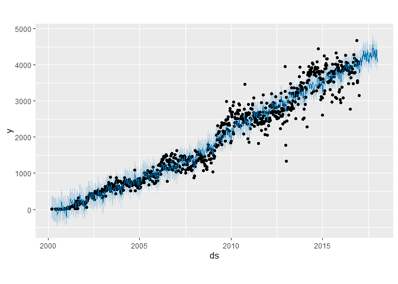

```r
plot(m, forecast)
```

We can look at the key feautres effecting the model

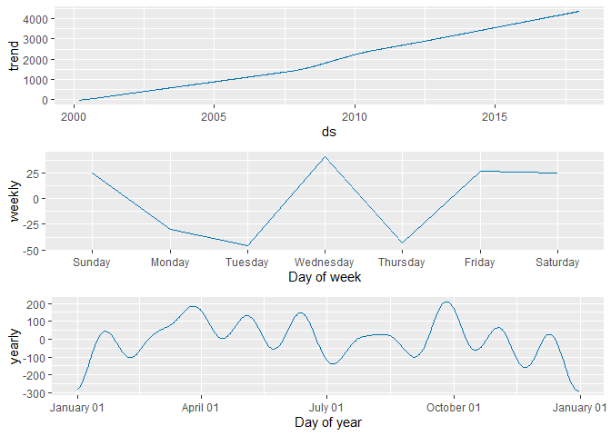

```r
prophet_plot_components(m, forecast)
```

and then visualize the predictions!

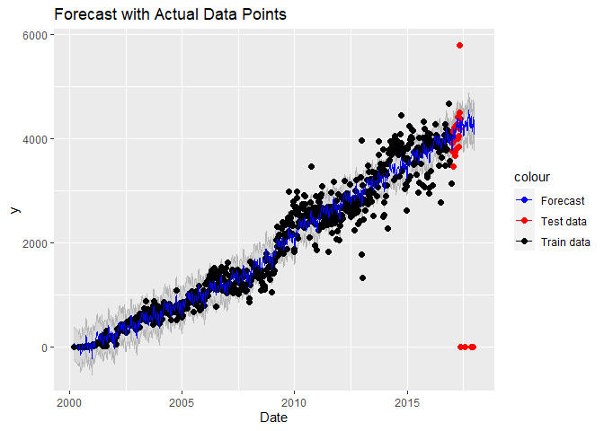

```r
# Plot the prophet forecast with the test data points
ggplot(forecast, aes(ds, yhat)) +
  geom_ribbon(data = forecast,aes(ymin=yhat_lower,ymax=yhat_upper), alpha=0.1, color = "grey71")+
  geom_point(data = GN_Data_Train, aes(ds, y, color = "train data"), size = 2) +
  geom_point(data = GN_Data_Test, aes(ds, y, color = "test data"), size = 2) +
  geom_line(aes(color = "prophet forecast")) +
  scale_color_manual(values = c("blue", "red", "black"), labels = c("Forecast", "Test data", "Train data")) +
  xlab("Date") +
  ylab("y") +
  ggtitle("Forecast with Actual Data Points")
```

We can also take a look at the model evaluation

```r
actuals <- GN_Data_Test$y
predictions <- tail(forecast$yhat,26)

MAE <- mean(abs(actuals - predictions))
MSE <- mean((actuals - predictions)^2)
```

```r
RMSE <- sqrt(MSE)
MAPE <- mean(abs(actuals - predictions) / actuals)
print(MAE)
```

```
## [1] 980.9874
```

```r
print(MSE)
```

```
## [1] 2926939
```

```r
print(RMSE)
```

```
## [1] 1710.83
```

```r
print(MAPE)
```

```
## [1] 516.0019
```

## 2017 with Hollidays

The last prediction is not as clear as we could have hopped for.

So let’s account for US publich Hollidays based on: https://www.commerce.gov/hr/employees/leave/holidays https://www.kaggle.com/datasets/donnetew/us-holiday-dates-2004-2021

```r
Stat_Holliday <- data_frame(
  holiday = 'StatHolliday',
  ds = as.Date(c('2004-07-04','2005-07-04','2006-07-04','2007-07-04',
                 '2008-07-04','2009-07-04','2010-07-04','2011-07-04',
                 '2012-07-04','2013-07-04','2014-07-04','2015-07-04',
                 '2016-07-04','2017-07-04','2018-07-04','2019-07-04',
                 '2020-07-04','2021-07-04','2004-12-25','2005-12-25',
                 '2006-12-25','2007-12-25','2008-12-25','2009-12-25',
                 '2010-12-25','2011-12-25','2012-12-25','2013-12-25',
                 '2014-12-25','2015-12-25','2016-12-25','2017-12-25',
                 '2018-12-25','2019-12-25','2020-12-25','2021-12-25','2004-12-24','2005-12-24','2006-12-24','2007-12-24','2008-12-24','2009-12-24','2010-12-24','2011-12-24','2012-12-24','2013-12-24','2014-12-24','2015-12-24','2016-12-24','2017-12-24','2018-12-24','2019-12-24','2020-12-24','2021-12-24','2007-10-08','2012-10-08','2018-10-08','2006-10-09','2017-10-09','2005-10-10','2011-10-10','2016-10-10','2004-10-11','2010-10-11','2021-10-11','2009-10-12','2015-10-12','2020-10-12','2008-10-13','2014-10-13','2013-10-14','2019-10-14','2010-04-04','2007-04-08','2018-04-08','2004-04-11','2015-04-12','2012-04-15','2017-04-16','2020-04-19','2009-04-19','2014-04-20','2006-04-23','2011-04-24','2008-04-27','2019-04-28','2021-05-02','2005-05-01','2016-05-01','2013-05-05','2020-06-19','2021-06-19','2004-06-19','2005-06-19','2006-06-19','2007-06-19','2008-06-19','2009-06-19','2010-06-19','2011-06-19','2012-06-19','2013-06-19','2014-06-19','2015-06-19','2016-06-19','2017-06-19','2018-06-19','2019-06-19','2008-09-01','2014-09-01','2013-09-02','2019-09-02','2007-09-03','2012-09-03','2018-09-03','2006-09-04','2017-09-04','2005-09-05','2011-09-05','2016-09-05','2004-09-06','2010-09-06','2021-09-06','2009-09-07','2015-09-07','2020-09-07','2008-08-30','2014-08-30','2008-08-31','2014-08-31','2013-08-31','2019-08-31','2013-09-01','2019-09-01','2007-09-01','2012-09-01','2018-09-01','2007-09-02','2012-09-02','2018-09-02','2006-09-02','2017-09-02','2006-09-03','2017-09-03','2005-09-03','2011-09-03','2016-09-03','2005-09-04','2011-09-04','2016-09-04','2004-09-04','2010-09-04','2021-09-04','2004-09-05','2010-09-05','2021-09-05','2009-09-05','2015-09-05','2020-09-05','2009-09-06','2015-09-06','2020-09-06','2007-01-15','2018-01-15','2006-01-16','2012-01-16','2017-01-16','2005-01-17','2011-01-17','2010-01-18','2016-01-18','2021-01-18','2004-01-19','2009-01-19','2015-01-19','2014-01-20','2020-01-20','2008-01-21','2013-01-21','2019-01-21','2009-05-25','2015-05-25','2020-05-25','2008-05-26','2014-05-26','2013-05-27','2019-05-27','2007-05-28','2012-05-28','2018-05-28','2006-05-29','2017-05-29','2005-05-30','2011-05-30','2016-05-30','2004-05-31','2010-05-31','2021-05-31','2012-01-01','2013-01-01','2014-01-01','2015-01-01','2016-01-01','2017-01-01','2018-01-01','2019-01-01','2020-01-01','2011-01-01','2004-01-01','2005-01-01','2006-01-01','2007-01-01','2008-01-01','2009-01-01','2010-01-01','2021-01-01','2004-12-31','2005-12-31','2006-12-31','2007-12-31','2008-12-31','2009-12-31','2010-12-31','2011-12-31','2012-12-31','2013-12-31','2014-12-31','2015-12-31','2016-12-31','2017-12-31','2018-12-31','2019-12-31','2020-12-31','2021-12-31','2007-11-22','2012-11-22','2018-11-22','2006-11-23','2017-11-23','2005-11-24','2011-11-24','2016-11-24','2004-11-25','2010-11-25','2021-11-25','2009-11-26','2015-11-26','2020-11-26','2008-11-27','2014-11-27','2013-11-28','2019-11-28','2007-11-21','2012-11-21','2018-11-21','2006-11-22','2017-11-22','2005-11-23','2011-11-23','2016-11-23','2004-11-24','2010-11-24','2021-11-24','2009-11-25','2015-11-25','2020-11-25','2008-11-26','2014-11-26','2013-11-27','2019-11-27','2004-02-14','2005-02-14','2006-02-14','2007-02-14','2008-02-14','2009-02-14','2010-02-14','2011-02-14','2012-02-14','2013-02-14','2014-02-14','2015-02-14','2016-02-14','2017-02-14','2018-02-14','2019-02-14','2020-02-14','2021-02-14','2004-11-11','2005-11-11','2006-11-11','2007-11-11','2008-11-11','2009-11-11','2010-11-11','2011-11-11','2012-11-11','2013-11-11','2014-11-11','2015-11-11','2016-11-11','2017-11-11','2018-11-11','2019-11-11','2020-11-11','2021-11-11','2016-02-15','2015-02-16','2014-02-17','2020-02-17','2013-02-18','2019-02-18','2018-02-19','2012-02-20','2017-02-20','2011-02-21','2010-02-15','2021-02-15','2004-02-16','2009-02-16','2008-02-18','2007-02-19','2006-02-20','2005-02-21','2008-03-23','2005-03-27','2016-03-27','2013-03-31','2018-04-01','2010-04-04','2021-04-04','2015-04-05','2007-04-08','2012-04-08','2004-04-11','2009-04-12','2020-04-12','2006-04-16','2017-04-16','2014-04-20','2019-04-21','2011-04-24'))
,
  lower_window = 0,
  upper_window = 1
)
holidays <- bind_rows(Stat_Holliday)
```

```r
m<-prophet(GN_Data_Train,holidays = holidays)
```

```
## Disabling daily seasonality. Run prophet with daily.seasonality=TRUE to override this.
```

```r
future <- make_future_dataframe(m, periods = 365)


forecast <- predict(m, future)
tail(future)
```

```
##              ds
## 1225 2017-12-21
## 1226 2017-12-22
## 1227 2017-12-23
## 1228 2017-12-24
## 1229 2017-12-25
## 1230 2017-12-26
```

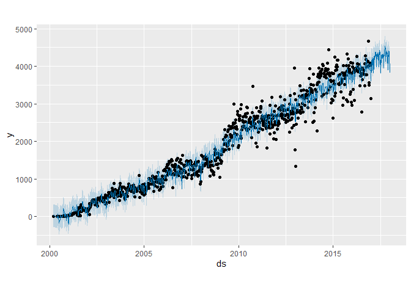

```r
plot(m, forecast)
```

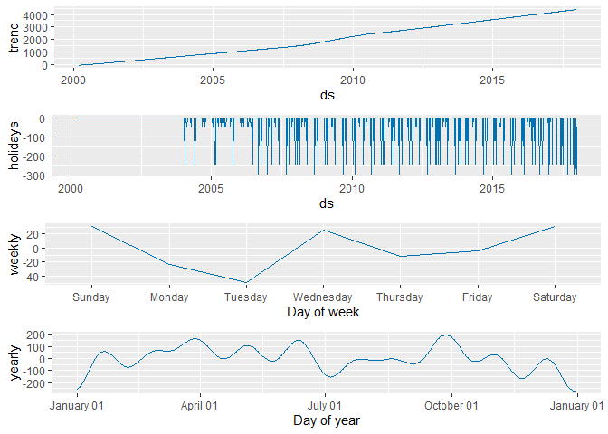

```r
prophet_plot_components(m, forecast)
```

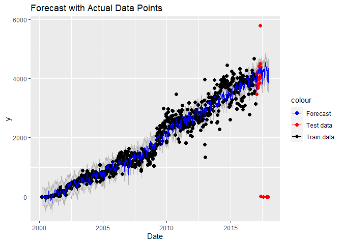

```r
# Plot the prophet forecast with the test data points
ggplot(forecast, aes(ds, yhat)) +
  geom_ribbon(data = forecast,aes(ymin=yhat_lower,ymax=yhat_upper), alpha=0.1, color = "grey71")+
  geom_point(data = GN_Data_Train, aes(ds, y, color = "train data"), size = 2) +
  geom_point(data = GN_Data_Test, aes(ds, y, color = "test data"), size = 2) +
  geom_line(aes(color = "prophet forecast")) +
  scale_color_manual(values = c("blue", "red", "black"), labels = c("Forecast", "Test data", "Train data")) +
  xlab("Date") +
  ylab("y") +
  ggtitle("Forecast with Actual Data Points")
```

We can also take a look at the model evaluation

```r
actuals <- GN_Data_Test$y
predictions <- tail(forecast$yhat,26)

MAE <- mean(abs(actuals - predictions))
MSE <- mean((actuals - predictions)^2)
```

```r
RMSE <- sqrt(MSE)
MAPE <- mean(abs(actuals - predictions) / actuals)
print(MAE)
```

```
## [1] 962.8091
```

```r
print(MSE)
```

```
## [1] 2872742
```

```r
print(RMSE)
```

```
## [1] 1694.917
```

```r
print(MAPE)
```

```
## [1] 508.7466
```

## 2016 data

Lets try removing 2017 data and predicting 2016 data instead

```r
fdate="2016-01-01"
edate="2017-01-01"
GN_Data_Train <- GN_Data %>%
  filter(ds< as.Date(fdate))

GN_Data_Test <- GN_Data %>%
  filter(ds>= as.Date(fdate))

GN_Data_Test <- GN_Data_Test %>%
  filter(ds<= as.Date(edate))

m<-prophet(GN_Data_Train)
```

```
## Disabling daily seasonality. Run prophet with daily.seasonality=TRUE to override this.
```

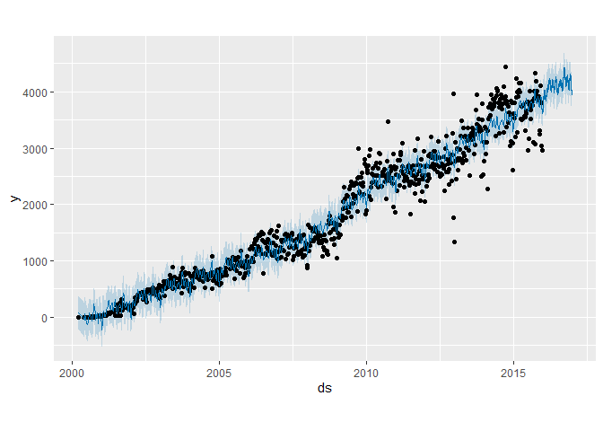

```r
future <- make_future_dataframe(m, periods = 365)
forecast <- predict(m, future)
plot(m,forecast)
```

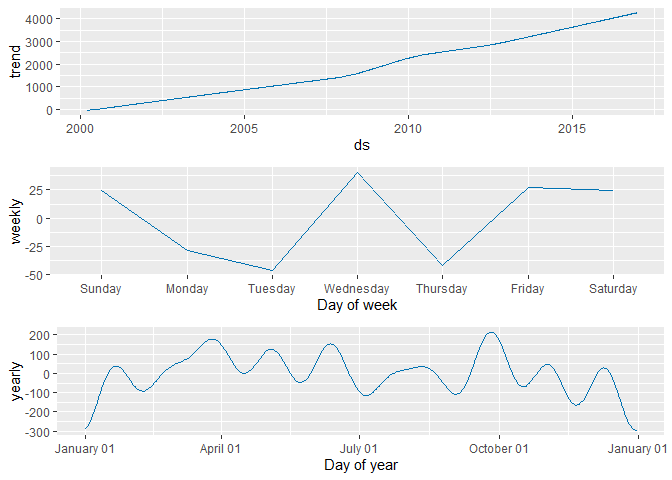

```r
prophet_plot_components(m, forecast)
```

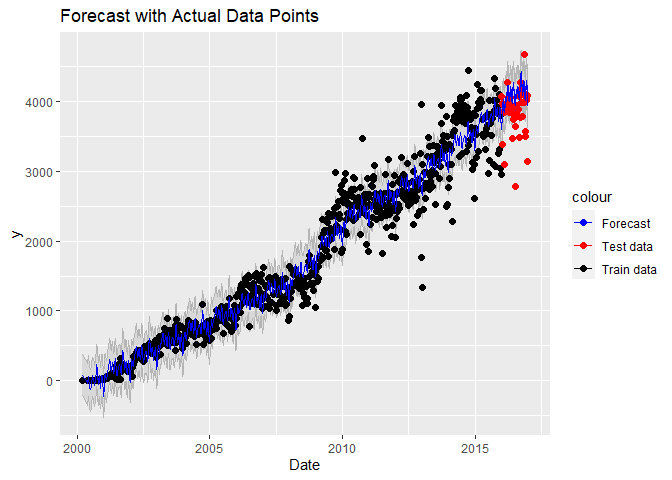

```r
ggplot(forecast, aes(ds, yhat)) +
  geom_ribbon(data = forecast,aes(ymin=yhat_lower,ymax=yhat_upper), alpha=0.1, color = "grey71")+
  geom_point(data = GN_Data_Train, aes(ds, y, color = "train data"), size = 2) +
  geom_point(data = GN_Data_Test, aes(ds, y, color = "test data"), size = 2) +
  geom_line(aes(color = "prophet forecast")) +
  scale_color_manual(values = c("blue", "red", "black"), labels = c("Forecast", "Test data", "Train data")) +
  xlab("Date") +
  ylab("y") +
  ggtitle("Forecast with Actual Data Points")
```

```r
actuals <- GN_Data_Test$y
predictions <- tail(forecast$yhat,52)

MAE <- mean(abs(actuals - predictions))
MSE <- mean((actuals - predictions)^2)
RMSE <- sqrt(MSE)
MAPE <- mean(abs(actuals - predictions) / actuals)


print(MAE)
```

```
## [1] 324.8052
```

```r
print(MSE)
```

```
## [1] 185234.2
```

```r
print(RMSE)
```

```
## [1] 430.3885
```

```r
print(MAPE)
```

```
## [1] 0.09044257
```

## 2016 data with hollidays

Lets try the same day with hollodays now

```r
m<-prophet(GN_Data_Train, holidays = holidays)
```

```
## Disabling daily seasonality. Run prophet with daily.seasonality=TRUE to override this.
```

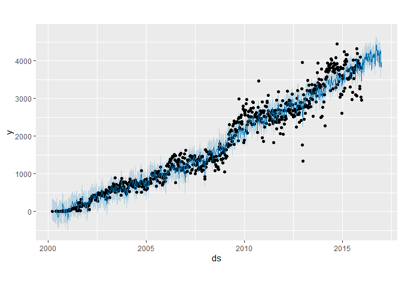

```r
future <- make_future_dataframe(m, periods = 365)
forecast <- predict(m, future)

plot(m,forecast)
```

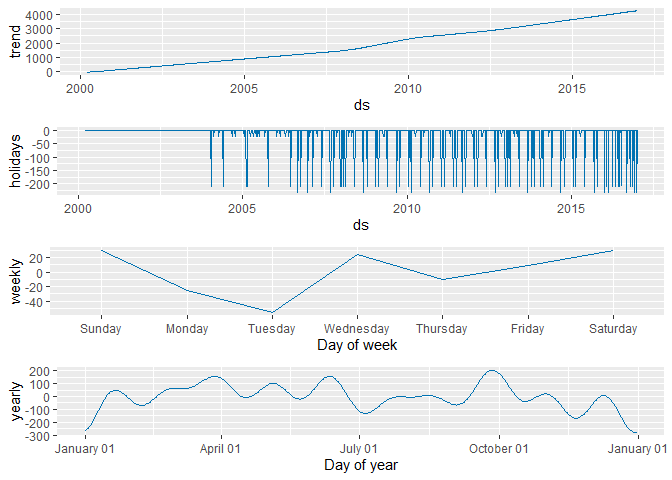

```r
prophet_plot_components(m, forecast)
```

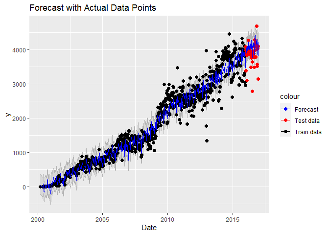

```r
ggplot(forecast, aes(ds, yhat)) +
  geom_ribbon(data = forecast,aes(ymin=yhat_lower,ymax=yhat_upper), alpha=0.1, color = "grey71")+
  geom_point(data = GN_Data_Train, aes(ds, y, color = "train data"), size = 2) +
  geom_point(data = GN_Data_Test, aes(ds, y, color = "test data"), size = 2) +
  geom_line(aes(color = "prophet forecast")) +
  scale_color_manual(values = c("blue", "red", "black"), labels = c("Forecast", "Test data", "Train data")) +
  xlab("Date") +
  ylab("y") +
  ggtitle("Forecast with Actual Data Points")
```

```r
actuals <- GN_Data_Test$y
predictions <- tail(forecast$yhat,52)

MAE <- mean(abs(actuals - predictions))
MSE <- mean((actuals - predictions)^2)
RMSE <- sqrt(MSE)
MAPE <- mean(abs(actuals - predictions) / actuals)

print(MAE)
```

```
## [1] 324.6266
```

```r
print(MSE)
```

```
## [1] 180519.6
```

```r
print(RMSE)
```

```
## [1] 424.8759
```

```r
print(MAPE)
```

```
## [1] 0.09021357
```

## Gender Data with 2016 Assumptions

Lets first clean up the data

```r
fdate="2016-01-01"
edate="2017-01-01"
F_Data_Train <- F_Data %>%
  filter(ds< as.Date(fdate))

F_Data_Test <- F_Data %>%
  filter(ds>= as.Date(fdate))

F_Data_Test <- F_Data_Test %>%
  filter(ds<= as.Date(edate))


M_Data_Train <- M_Data %>%
  filter(ds< as.Date(fdate))

M_Data_Test <- M_Data %>%
  filter(ds>= as.Date(fdate))

M_Data_Test <- M_Data_Test %>%
  filter(ds<= as.Date(edate))
```

```r
m_F<-prophet(F_Data_Train,holidays=holidays)
```

```
## Disabling daily seasonality. Run prophet with daily.seasonality=TRUE to override this.
```

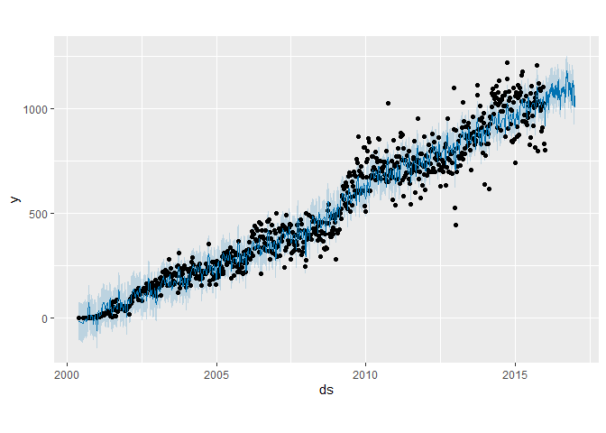

```r
future <- make_future_dataframe(m_F, periods = 365)
forecast_F <- predict(m_F, future)
plot(m_F,forecast_F)
```

```r
m_M<-prophet(M_Data_Train ,holidays=holidays)
```

```
## Disabling daily seasonality. Run prophet with daily.seasonality=TRUE to override this.
```

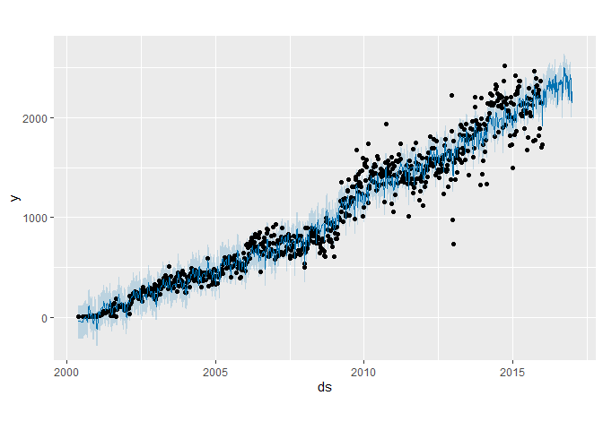

```r
future <- make_future_dataframe(m_M, periods = 365)
forecast_M <- predict(m_M, future)
plot(m_M,forecast_M)
```

[figure not shown]

```r
ggplot(forecast, aes(ds, yhat)) +
  geom_ribbon(data = forecast_F,aes(ymin=yhat_lower,ymax=yhat_upper), alpha=0.4, color = "lightpink")+
  geom_ribbon(data = forecast_M,aes(ymin=yhat_lower,ymax=yhat_upper), alpha=0.4, color = "lightblue")+
  geom_point(data = F_Data_Train, aes(ds, y, color = "train data Femal"), size = 2, alpha=.2) +
  geom_point(data = F_Data_Test, aes(ds, y, color = "test data Female"), size = 2, alpha=.2) +
  geom_point(data = M_Data_Train, aes(ds, y, color = "train data Male"), size = 2,alpha=.2) +
  geom_point(data = M_Data_Test, aes(ds, y, color = "test data Male"), size = 2,alpha=.2) +
  scale_color_manual(values = c("magenta", "darkblue","pink2","lightblue3","black"), labels = c("Test Data Female", "Test data Male", "Training Data Female", "Test Data Female")) +
  xlab("Date") +
  ylab("y") +
  ggtitle("Forecast with Actual Data Points")
```

```r
actuals <- M_Data_Test$y
predictions <- tail(forecast_M$yhat,52)

MAE <- mean(abs(actuals - predictions))
MSE <- mean((actuals - predictions)^2)
RMSE <- sqrt(MSE)
MAPE <- mean(abs(actuals - predictions) / actuals)

print(MAE)
```

```
## [1] 164.1063
```

```r
print(MSE)
```

```
## [1] 48468.04
```

```r
print(RMSE)
```

```
## [1] 220.1546
```

```r
print(MAPE)
```

```
## [1] 0.07886121
```

```r
actuals <- F_Data_Test$y
predictions <- tail(forecast_F$yhat,52)

MAE <- mean(abs(actuals - predictions))
MSE <- mean((actuals - predictions)^2)
RMSE <- sqrt(MSE)
MAPE <- mean(abs(actuals - predictions) / actuals)

print(MAE)
```

```
## [1] 88.31198
```

```r
print(MSE)
```

```
## [1] 13213.5
```

```r
print(RMSE)
```

```
## [1] 114.95
```

```r
print(MAPE)
```

```
## [1] 0.09214144
```